# Personal Loan Campaign Project

### Visualizing the Decision Tree

```python
column_names = list(X.columns)
feature_names = column_names
print(feature_names)
```

[output not shown]

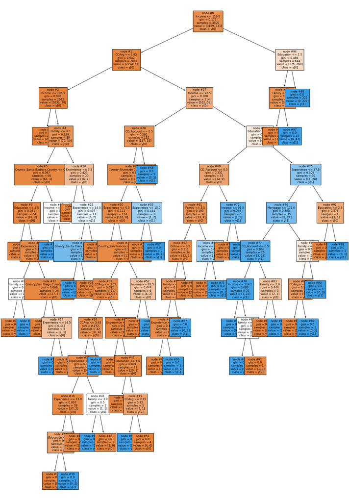

```python
plt.figure(figsize=(20, 30))
plt.figure(figsize=(20, 30))

out = tree.plot_tree(
    dtmodel,
    feature_names=feature_names,
    filled=True,
    fontsize=9,
    node_ids=True,
    class_names=True,
)
for o in out:
    arrow = o.arrow_patch
    if arrow is not None:
        arrow.set_edgecolor("black")
        arrow.set_linewidth(1)
plt.show()
```

```python
# Text report showing the rules of a decision tree -

print(tree.export_text(dtmodel, feature_names=feature_names, show_weights=True))
```

```
|--- Income <= 116.50
|   |--- CCAvg <= 2.95
|   |   |--- Income <= 106.50
|   |   |   |--- weights: [2553.00, 0.00] class: 0
|   |   |--- Income >  106.50
|   |   |   |--- Family <= 3.50
|   |   |   |   |--- County_Santa Barbara County <= 0.50
|   |   |   |   |   |--- Education <= 1.50
|   |   |   |   |   |   |--- weights: [34.00, 0.00] class: 0
|   |   |   |   |   |--- Education >  1.50
|   |   |   |   |   |   |--- Experience <= 4.50
|   |   |   |   |   |   |   |--- Family <= 1.50
|   |   |   |   |   |   |   |   |--- weights: [1.00, 0.00] class: 0
|   |   |   |   |   |   |   |--- Family >  1.50
|   |   |   |   |   |   |   |   |--- weights: [0.00, 1.00] class: 1
|   |   |   |   |   |   |--- Experience >  4.50
|   |   |   |   |   |   |   |--- County_San Diego County <= 0.50
|   |   |   |   |   |   |   |   |--- weights: [25.00, 0.00] class: 0
|   |   |   |   |   |   |   |--- County_San Diego County >  0.50
|   |   |   |   |   |   |   |   |--- Experience <= 24.50
|   |   |   |   |   |   |   |   |   |--- weights: [0.00, 1.00] class: 1
|   |   |   |   |   |   |   |   |--- Experience >  24.50
|   |   |   |   |   |   |   |   |   |--- weights: [2.00, 0.00] class: 0
|   |   |   |   |--- County_Santa Barbara County >  0.50
|   |   |   |   |   |--- Income <= 112.00
|   |   |   |   |   |   |--- weights: [0.00, 1.00] class: 1
|   |   |   |   |   |--- Income >  112.00
|   |   |   |   |   |   |--- weights: [1.00, 0.00] class: 0
|   |   |   |--- Family >  3.50
|   |   |   |   |--- Experience <= 3.50
|   |   |   |   |   |--- weights: [10.00, 0.00] class: 0
|   |   |   |   |--- Experience >  3.50
|   |   |   |   |   |--- Experience <= 34.00
|   |   |   |   |   |   |--- County_Santa Clara County <= 0.50
|   |   |   |   |   |   |   |--- weights: [0.00, 7.00] class: 1
|   |   |   |   |   |   |--- County_Santa Clara County >  0.50
|   |   |   |   |   |   |   |--- weights: [2.00, 0.00] class: 0
|   |   |   |   |   |--- Experience >  34.00
|   |   |   |   |   |   |--- weights: [4.00, 0.00] class: 0
|   |--- CCAvg >  2.95
```

[output cut: 90 more lines]

```
|   |   |   |   |   |   |--- Family >  2.50
|   |   |   |   |   |   |   |--- weights: [0.00, 3.00] class: 1
|   |   |   |   |--- Experience >  37.50
|   |   |   |   |   |--- Education <= 2.50
|   |   |   |   |   |   |--- weights: [3.00, 0.00] class: 0
|   |   |   |   |   |--- Education >  2.50
|   |   |   |   |   |   |--- weights: [0.00, 1.00] class: 1
|--- Income >  116.50
|   |--- Education <= 1.50
|   |   |--- Family <= 2.50
|   |   |   |--- weights: [375.00, 0.00] class: 0
|   |   |--- Family >  2.50
|   |   |   |--- weights: [0.00, 47.00] class: 1
|   |--- Education >  1.50
|   |   |--- weights: [0.00, 222.00] class: 1
```

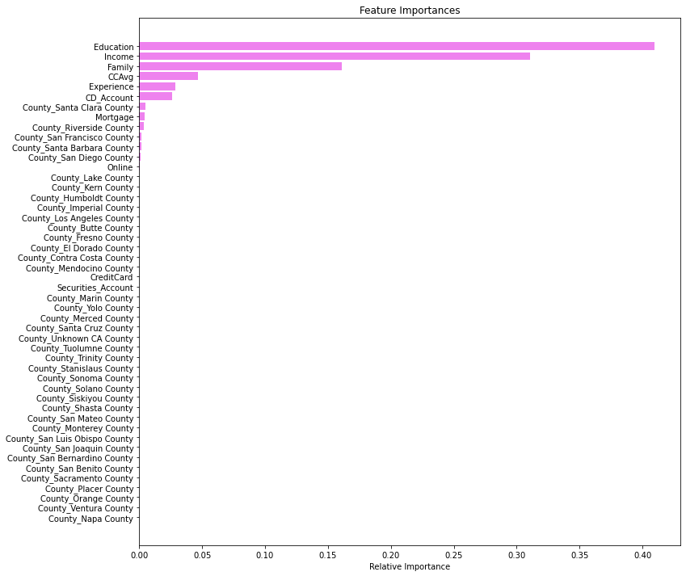

```python
importances = dtmodel.feature_importances_
indices = np.argsort(importances)

plt.figure(figsize=(12, 12))
plt.title("Feature Importances")
plt.barh(range(len(indices)), importances[indices], color="violet", align="center")
plt.yticks(range(len(indices)), [feature_names[i] for i in indices])
plt.xlabel("Relative Importance")
plt.show()
```

Observation

- Education, Income, Family and CCAvg are the top 4 features to consider

### Using GridSearch for Hyperparameter tuning of our tree model

```python
# Choose the type of classifier.
estimator = DecisionTreeClassifier(random_state=1)

# Grid of parameters to choose from

parameters = {
    "max_depth": [np.arange(2, 50, 5), None],
    "criterion": ["entropy", "gini"],
    "splitter": ["best", "random"],
    "min_impurity_decrease": [0.000001, 0.00001, 0.0001],
}

# Type of scoring used to compare parameter combinations
acc_scorer = make_scorer(recall_score)

# Run the grid search
grid_obj = GridSearchCV(estimator, parameters, scoring=acc_scorer, cv=5)
grid_obj = grid_obj.fit(X_train, y_train)

# Set the clf to the best combination of parameters
estimator = grid_obj.best_estimator_

# Fit the best algorithm to the data.
estimator.fit(X_train, y_train)
```

```
DecisionTreeClassifier(criterion='entropy', min_impurity_decrease=1e-06,
                       random_state=1)
```

#### Checking Performance on Training Model

```python
decision_tree_tune_perf_train = model_performance_classification_sklearn(
    estimator, X_train, y_train
)
decision_tree_tune_perf_train
```

|  | Accuracy | Recall | Precision | F1 |
| --- | --- | --- | --- | --- |
| 0 | 1.0 | 1.0 | 1.0 | 1.0 |

#### Checking Performance on Testing Model

```python
decision_tree_tune_perf_test = model_performance_classification_sklearn(
    estimator, X_test, y_test
)

decision_tree_tune_perf_test
```

|  | Accuracy | Recall | Precision | F1 |
| --- | --- | --- | --- | --- |
| 0 | 0.98 | 0.85906 | 0.934307 | 0.895105 |

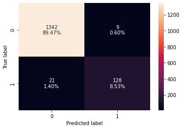

```python
confusion_matrix_sklearn(estimator, X_test, y_test)
```

#### Tree after Hyperparameter pruning

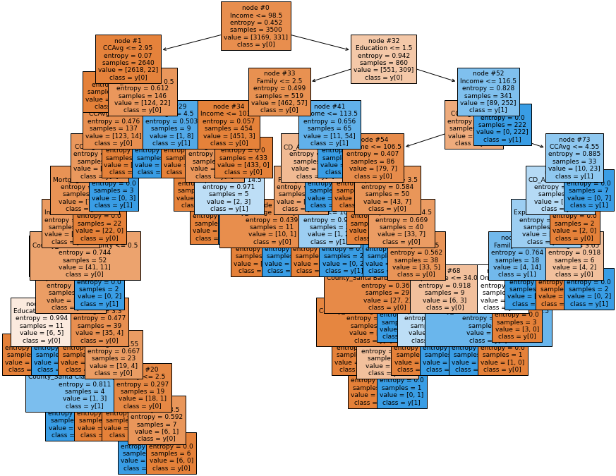

```python
plt.figure(figsize=(15, 12))

tree.plot_tree(
    estimator,
    feature_names=feature_names,
    filled=True,
    fontsize=9,
    node_ids=True,
    class_names=True,
)
plt.show()
```

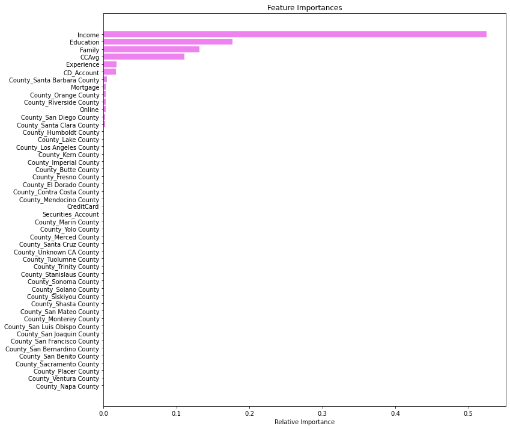

```python
importances = estimator.feature_importances_
indices = np.argsort(importances)

plt.figure(figsize=(12, 12))
plt.title("Feature Importances")
plt.barh(range(len(indices)), importances[indices], color="violet", align="center")
plt.yticks(range(len(indices)), [feature_names[i] for i in indices])
plt.xlabel("Relative Importance")
plt.show()
```

Observation

- In the tuned model Income is most important feature, that business should focus on

### Using Cost Complexity Pruning

```python
clf = DecisionTreeClassifier(random_state=1)
path = clf.cost_complexity_pruning_path(X_train, y_train)
ccp_alphas, impurities = path.ccp_alphas, path.impurities
```

```python
pd.DataFrame(path)
```

|  | ccp_alphas | impurities |
| --- | --- | --- |
| 0 | 0.000000 | 0.000000 |
| 1 | 0.000188 | 0.000564 |
| 2 | 0.000221 | 0.001671 |
| 3 | 0.000265 | 0.002200 |
| 4 | 0.000273 | 0.002747 |
| 5 | 0.000286 | 0.003032 |
| 6 | 0.000359 | 0.004108 |
| 7 | 0.000377 | 0.005994 |
| 8 | 0.000381 | 0.006375 |
| 9 | 0.000381 | 0.006756 |
| 10 | 0.000381 | 0.007136 |
| 11 | 0.000429 | 0.007565 |
| 12 | 0.000476 | 0.008041 |
| 13 | 0.000476 | 0.008517 |
| 14 | 0.000514 | 0.010059 |
| 15 | 0.000582 | 0.010641 |
| 16 | 0.000589 | 0.011230 |
| 17 | 0.000607 | 0.011837 |
| 18 | 0.000697 | 0.013928 |
| 19 | 0.000811 | 0.017985 |
| 20 | 0.001552 | 0.019536 |
| 21 | 0.002333 | 0.021869 |
| 22 | 0.003024 | 0.024893 |
| 23 | 0.003294 | 0.028187 |
| 24 | 0.006473 | 0.034659 |
| 25 | 0.023866 | 0.058525 |
| 26 | 0.056365 | 0.171255 |

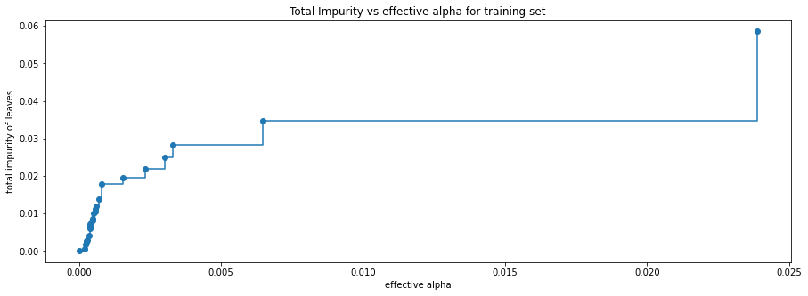

```python
fig, ax = plt.subplots(figsize=(15, 5))
ax.plot(ccp_alphas[:-1], impurities[:-1], marker="o", drawstyle="steps-post")
ax.set_xlabel("effective alpha")
ax.set_ylabel("total impurity of leaves")
ax.set_title("Total Impurity vs effective alpha for training set")
plt.show()
```

```python
clfs = []
for ccp_alpha in ccp_alphas:
    clf = DecisionTreeClassifier(random_state=1, ccp_alpha=ccp_alpha)
    clf.fit(X_train, y_train)
    clfs.append(clf)
print(
    "Number of nodes in the last tree is: {} with ccp_alpha: {}".format(
        clfs[-1].tree_.node_count, ccp_alphas[-1]
    )
)
```

```
Number of nodes in the last tree is: 1 with ccp_alpha: 0.056364969335601575
```

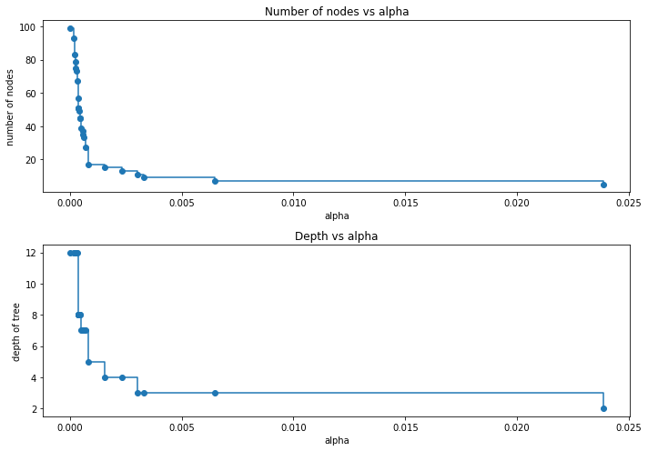

```python
clfs = clfs[:-1]
ccp_alphas = ccp_alphas[:-1]

node_counts = [clf.tree_.node_count for clf in clfs]
depth = [clf.tree_.max_depth for clf in clfs]
fig, ax = plt.subplots(2, 1, figsize=(10, 7))
ax[0].plot(ccp_alphas, node_counts, marker="o", drawstyle="steps-post")
ax[0].set_xlabel("alpha")
ax[0].set_ylabel("number of nodes")
ax[0].set_title("Number of nodes vs alpha")
ax[1].plot(ccp_alphas, depth, marker="o", drawstyle="steps-post")
ax[1].set_xlabel("alpha")
ax[1].set_ylabel("depth of tree")
ax[1].set_title("Depth vs alpha")
fig.tight_layout()
```

### Recall vs alpha for training and testing sets

```python
recall_train = []
for clf in clfs:
    pred_train = clf.predict(X_train)
    values_train = recall_score(y_train, pred_train)
    recall_train.append(values_train)
```

```python
recall_test = []
for clf in clfs:
    pred_test = clf.predict(X_test)
    values_test = recall_score(y_test, pred_test)
    recall_test.append(values_test)
```

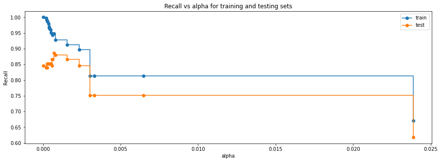

```python
fig, ax = plt.subplots(figsize=(15, 5))
ax.set_xlabel("alpha")
ax.set_ylabel("Recall")
ax.set_title("Recall vs alpha for training and testing sets")
ax.plot(ccp_alphas, recall_train, marker="o", label="train", drawstyle="steps-post")
ax.plot(ccp_alphas, recall_test, marker="o", label="test", drawstyle="steps-post")
ax.legend()
plt.show()
```

```python
# creating the model where we get highest train and test recall
index_best_model = np.argmax(recall_test)
best_model = clfs[index_best_model]
print(best_model)
```

```
DecisionTreeClassifier(ccp_alpha=0.0006971916971916974, random_state=1)
```

#### Checking model performance on training set

```python
decision_tree_postpruned_perf_train = model_performance_classification_sklearn(
    best_model, X_train, y_train
)
decision_tree_postpruned_perf_train
```

|  | Accuracy | Recall | Precision | F1 |
| --- | --- | --- | --- | --- |
| 0 | 0.991714 | 0.94864 | 0.96319 | 0.95586 |

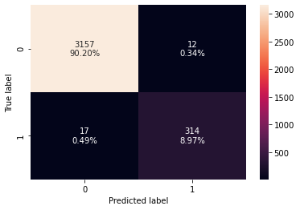

```python
confusion_matrix_sklearn(best_model, X_train, y_train)
```

#### Checking model performance on test set

```python
decision_tree_postpruned_perf_test = model_performance_classification_sklearn(
    best_model, X_test, y_test
)
decision_tree_postpruned_perf_test
```

|  | Accuracy | Recall | Precision | F1 |
| --- | --- | --- | --- | --- |
| 0 | 0.982 | 0.885906 | 0.929577 | 0.907216 |

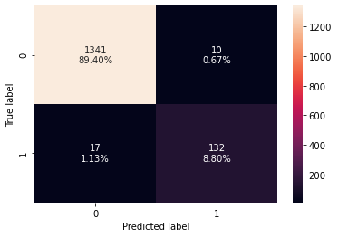

```python
confusion_matrix_sklearn(best_model, X_test, y_test)
```

Observation

- The recall value has improved a bit

#### Visualizing the Decision Tree

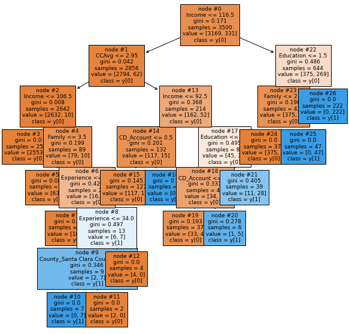

```python
plt.figure(figsize=(10, 10))

out = tree.plot_tree(
    best_model,
    feature_names=feature_names,
    filled=True,
    fontsize=9,
    node_ids=True,
    class_names=True,
)
for o in out:
    arrow = o.arrow_patch
    if arrow is not None:
        arrow.set_edgecolor("black")
        arrow.set_linewidth(1)
plt.show()
plt.show()
```

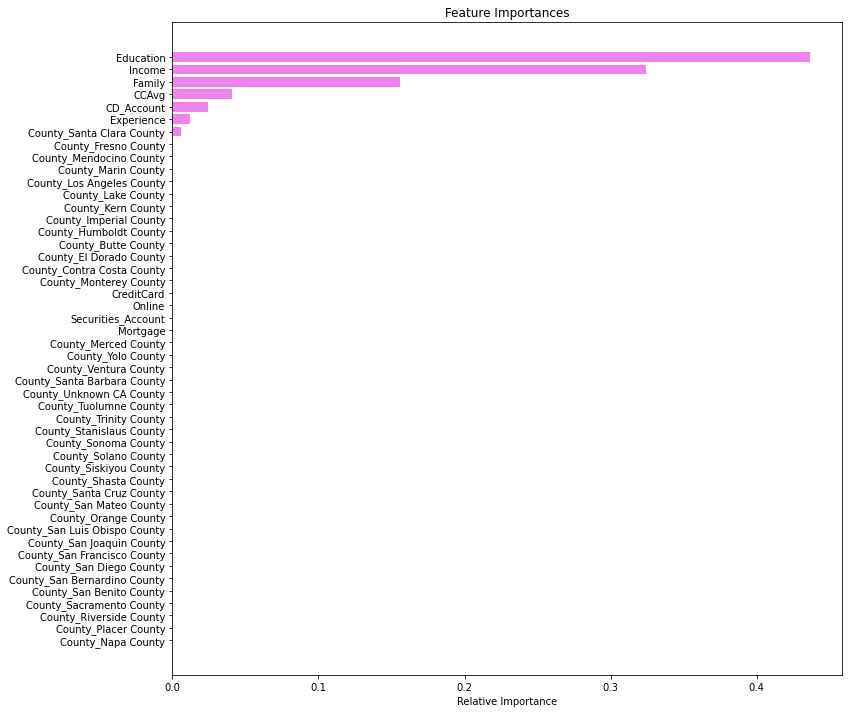

```python
importances = best_model.feature_importances_
indices = np.argsort(importances)

plt.figure(figsize=(12, 12))
plt.title("Feature Importances")
plt.barh(range(len(indices)), importances[indices], color="violet", align="center")
plt.yticks(range(len(indices)), [feature_names[i] for i in indices])
plt.xlabel("Relative Importance")
plt.show()
```

Observation

- Education , Income, Family and CCAvg are the important features in Post Pruning
- Number of significant features has reduced significantly in Post Pruning

### Comparing all the decision tree models

```python
# training performance comparison

models_train_comp_df = pd.concat(
    [
        decision_tree_perf_train.T,
        decision_tree_tune_perf_train.T,
        decision_tree_postpruned_perf_train.T,
    ],
    axis=1,
)
models_train_comp_df.columns = [
    "Decision Tree sklearn",
    "Decision Tree (Pre-Pruning)",
    "Decision Tree (Post-Pruning)",
]
print("Training performance comparison:")
models_train_comp_df
```

```
Training performance comparison:
```

|  | Decision Tree sklearn | Decision Tree (Pre-Pruning) | Decision Tree (Post-Pruning) |
| --- | --- | --- | --- |
| Accuracy | 1.0 | 1.0 | 0.991714 |
| Recall | 1.0 | 1.0 | 0.948640 |
| Precision | 1.0 | 1.0 | 0.963190 |
| F1 | 1.0 | 1.0 | 0.955860 |

```python
# test performance comparison

models_train_comp_df = pd.concat(
    [
        decision_tree_perf_test.T,
        decision_tree_tune_perf_test.T,
        decision_tree_postpruned_perf_test.T,
    ],
    axis=1,
)
models_train_comp_df.columns = [
    "Decision Tree sklearn",
    "Decision Tree (Pre-Pruning)",
    "Decision Tree (Post-Pruning)",
]
print("Test set performance comparison:")
models_train_comp_df
```

```
Test set performance comparison:
```

|  | Decision Tree sklearn | Decision Tree (Pre-Pruning) | Decision Tree (Post-Pruning) |
| --- | --- | --- | --- |
| Accuracy | 0.976000 | 0.980000 | 0.982000 |
| Recall | 0.845638 | 0.859060 | 0.885906 |
| Precision | 0.906475 | 0.934307 | 0.929577 |
| F1 | 0.875000 | 0.895105 | 0.907216 |

Observation

- Decision tree with post-pruning is giving the highest recall on the test set.

### Conclusion of Decision Tree Model

- Both Logistic Regresion Model and Decision Tree Models gave almost similar outcomes , thus increasing the confidence levels of this exercise.
- Post Pruning has provided a better Recall value
- Education , Income, Family and CCAvg are the important features in Post Pruning
- Other important variables are CD_Account, Experience.
- On the counties Santa Clara is a county which can be focused, (Post Pruning) Santa Barbara county (Pre-Pruning)

### Business Insights for Marketing team

- Marketing campaigns for Personal Loans should target people with higher Education, Income , Family size and Credi Card Average in the order.
- These selective campaigns targetting special groups may yield better conversion rates.
- Having CD Account / Experience also shows a higher probability of availing a Personal Loan from the bank
- Customers living in metro counties like Sata Clara, Santa Barbara and Orange County will be more willing to avail a Personal Loan.
- Customers in rural counties may not be positive targets for Personal Loan merketing campaign
- Factors like Credit Card, Mortgage, Securities Account, Online Account are not positive , on the conversion rate of a marketing campaign.
- Experience is not a major factor in targetting, to a set of prospective customers . Also Age is another variable in the dataset which has direct correlation with Experience.
- Based on the above, the marketing campaigns can be targetted for all age groups, but higher Income Age groups (based on Education) also should be the focus of the campaign.
- Based on the inferences from Logistic and Decision Tree modeling, negative parameters are Credit Card.. (Credit Card customers may be availing the benefits of revolving credit). If the Personal Loan campaign can target about the benfits of a bank loan, compared to credit card, rolling balance, and higher interest rates, it would help to attract those customers.
- Similarly Mortgage customers, can be targetted for other products like Home Equity Loans or better refinancing options by the bank
- Securities Account users may also be targetted with focussed ads in their respective channels
- Online customers, may be availing personal loans from other competitive sources, so marketing campaign should focus on building a campaign to distinguish their products from others in the online market place.